# Reproducible Research: Peer Assessment 1

Crystal Kizer

October 21, 2020

Loading and preprocessing the data:

```r
#Loading Data to read file
setwd("C:/Users/AF03941/Documents/Coursera")
activity<-read.csv("activity.csv")
```

Process/transform the data into a format suitable for your analysis

```r
#process data. Review activity file to understand the dataset
dim(activity)
```

```
## [1] 17568     3
```

```r
names(activity)
```

```
## [1] "steps"    "date"     "interval"
```

```r
head(activity)
```

```
##   steps       date interval
## 1    NA 2012-10-01        0
## 2    NA 2012-10-01        5
## 3    NA 2012-10-01       10
## 4    NA 2012-10-01       15
## 5    NA 2012-10-01       20
## 6    NA 2012-10-01       25
```

```r
str(activity)
```

```
## 'data.frame':    17568 obs. of  3 variables:
##  $ steps   : int  NA NA NA NA NA NA NA NA NA NA ...
##  $ date    : chr  "2012-10-01" "2012-10-01" "2012-10-01" "2012-10-01" ...
##  $ interval: int  0 5 10 15 20 25 30 35 40 45 ...
```

```r
#formats date
activity$date <- as.Date(activity$date, "%Y-%m-%d")
#remove NA from data file
head(activity[which(!is.na(activity$steps)), ])
```

```
##     steps       date interval
## 289     0 2012-10-02        0
## 290     0 2012-10-02        5
## 291     0 2012-10-02       10
## 292     0 2012-10-02       15
## 293     0 2012-10-02       20
## 294     0 2012-10-02       25
```

```r
# Calculate the total number of steps taken per day
total_steps <- aggregate(steps ~ date, activity, sum )
names(total_steps)[names(total_steps)=="steps"] <- "total_steps"
 total_steps
```

```
##          date total_steps
## 1  2012-10-02         126
## 2  2012-10-03       11352
## 3  2012-10-04       12116
## 4  2012-10-05       13294
## 5  2012-10-06       15420
## 6  2012-10-07       11015
## 7  2012-10-09       12811
## 8  2012-10-10        9900
## 9  2012-10-11       10304
## 10 2012-10-12       17382
## 11 2012-10-13       12426
## 12 2012-10-14       15098
## 13 2012-10-15       10139
## 14 2012-10-16       15084
```

[output cut: 39 more lines]

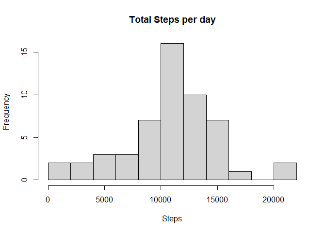

```r
# Make a histogram of the total number of steps taken each day
sumSteps <- aggregate(activity$steps ~ activity$date, FUN=sum)
colnames(sumSteps)<- c("Date", "Steps")
 hist(sumSteps$Steps, breaks=10, xlab="Steps", main = "Total Steps per day")
```

Calculate and report the mean and median of the total number of steps taken per day

```r
#MEAN Steps per day:
as.integer(mean(sumSteps$Steps))
```

```
## [1] 10766
```

```r
#MEDIAN Steps per day:
as.integer(median(sumSteps$Steps))
```

```
## [1] 10765
```

What is the average daily activity pattern?

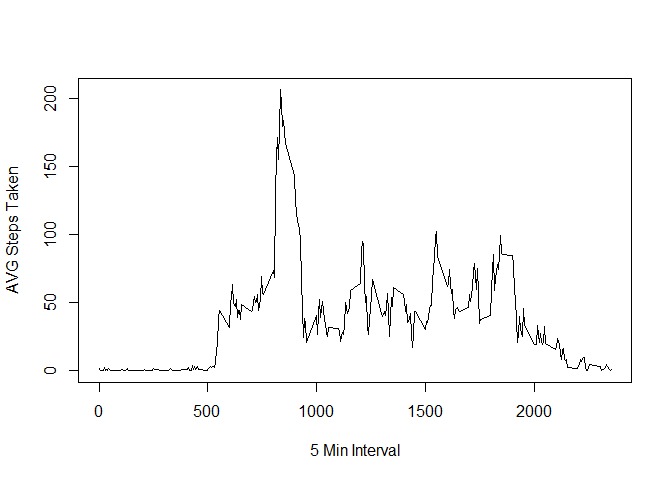

```r
#Make a time series plot of the 5-minute interval (x-axis) and the average number of steps taken, averaged across all days (y-axis)

 #calculate mean steps by 5 min interval
x <- aggregate(steps ~ interval, activity, mean, na.rm=TRUE)

 # plot time series chart and label accordingly
 plot(x, type="l", xlab="5 Min Interval", ylab="AVG Steps Taken")
```

Which 5-minute interval, on average across all the days in the dataset, contains the maximum number of steps?

```r
# get the interval which has the most steps
x$interval[x$steps==max(x$steps)]
```

```
## [1] 835
```

Imputing missing value: Calculate and report the total number of missing values in the dataset

```r
sum(is.na(activity$steps))
```

```
## [1] 2304
```

Devise a strategy for filling in all of the missing values in the dataset. Create a new dataset that is equal to the original dataset but with the missing data filled in

```r
# create the new dataset to fill in values for NA
 Fillin <- activity
# substitute NA with zeros in dataset
 Fillin$steps[is.na(Fillin$steps)] <- 0
# make sure there are no NAs in dataset
 sum(is.na(Fillin$steps))
```

```
## [1] 0
```

```r
# validate the dataset is equal to the original dataset but with the missing data filled in as 0s
sum(!is.na(Fillin$steps))
```

```
## [1] 17568
```

Make a histogram of the total number of steps taken each day and Calculate and report the mean and median total number of steps taken per day.

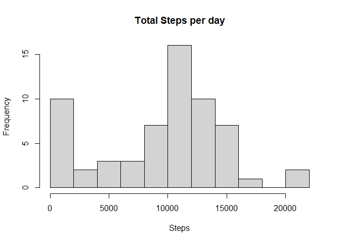

```r
TotalSteps2 <- aggregate(Fillin$steps ~ Fillin$date, FUN=sum)
colnames(TotalSteps2)<- c("Date", "Steps")

  #Create histogram of total number of steps
 hist(TotalSteps2$Steps, breaks=10, xlab="Steps", main = "Total Steps per day")
```

```r
#report the mean and median total number of steps taken per day
#Mean steps per day
as.integer(mean(TotalSteps2$Steps))
```

```
## [1] 9354
```

```r
#Median steps per day
as.integer(median(TotalSteps2$Steps))
```

```
## [1] 10395
```

```r
#Do these values differ from the estimates from the first part of the assignment?
#Yes, filling in the missing values to 0 skewed the data closer to 0. We can see there are more 0 values in our historgram.
#What is the impact of imputing missing data on the estimates of the total daily number of steps?
#Decreased both mean and median
```

Are there differences in activity patterns between weekdays and weekends?

Create a new factor variable in the dataset with two levels – “weekday” and “weekend” indicating whether a given date is a weekday or weekend day.

```r
#create weekday and weekend variable
activity$dayType <- sapply(activity$date, function(x) {
  if(weekdays(x) == "Saturday" | weekdays(x) == "Sunday")
  {y <- "Weekend"}
  else {y <- "Weekday"}
  y
})
```

Make a panel plot containing a time series plot of the 5-minute interval (x-axis) and the average number of steps taken, averaged across all weekday days or weekend days (y-axis)

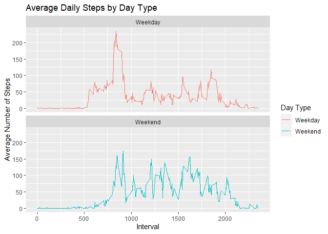

```r
 #Creating the data set that will be plotted using new weekday and weekend variables
activityByDay <-  aggregate(steps ~ interval + dayType, activity, mean, na.rm = TRUE)


library(ggplot2)

#Plotting panel plot using ggplot2
dayPlot <-  ggplot(activityByDay, aes(x = interval , y = steps, color = dayType)) +
  geom_line() + ggtitle("Average Daily Steps by Day Type") +
  xlab("Interval") +
  ylab("Average Number of Steps") +
  facet_wrap(~dayType, ncol = 1, nrow=2) +
  scale_color_discrete(name = "Day Type")

print(dayPlot)
```